```python
import numpy as np
import matplotlib.pyplot as plt
import cvxpy as cvx
from scipy import stats, misc
import numpy.matlib

%matplotlib inline
import warnings
warnings.filterwarnings('ignore')
```

**Logistic Regression**

Table of Contents

# 1. Linear Classification: Logistic Regression

## 1.1. Using all Distances

- Logistic regression is a classification algorithm - don't be confused
- Perceptron: make use of sign of data
- SVM: make use of margin (minimum distance)
- We want to use *distance information of all data points* $\rightarrow$ logistic regression

[figure not shown]

- basic idea: find the decision boundary (hyperplane) of $g(x)=\omega^T x =0$ such that maximizes $\prod_i \lvert h_i \rvert$
  - Inequality of arithmetic and geometric means $$ \frac{h_1+h_2}{2} \geq \sqrt{h_1 h_2} $$ and that equality holds if and only if $h_1 = h_2$
- Roughly speaking, this optimization of $\max \prod_i \lvert h_i \rvert$ tends to position a hyperplane in the middle of two classes

$$h = \frac{g(x)}{\lVert \omega \rVert} = \frac{\omega^T x}{\lVert \omega \rVert} \sim \omega^T x$$

- We link or squeeze $(-\infty, +\infty)$ to $(0,1)$ for several reasons:

[figure not shown]

```
(-0.1, 1.1)
```

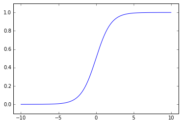

```python
z = [x/10. for x in range(-100, 101)]
z = np.array(z)
s = 1./(1+np.exp(-z))
plt.plot(z, s)
plt.xlim([-11, 11])
plt.ylim([-0.1, 1.1])
```

- Benefit of mapping via the logistic function
  - monotonic: same or similar optimziation solution
  - continuous and differentiable: good for gradient descent optimization
  - probability or confidence: can be considered as probability

  $$P\left(y = +1 \mid x,\omega\right) = \frac{1}{1+e^{-\omega^T x}} \in [0,1]$$
  - Often we do note care about predicting the label $y$ for an example
  - Rather, we want to predict the label probabilities $P\left(y \mid x,\omega\right)$
    - the probability that the label is $+1$ $$P\left(y = +1 \mid x,\omega\right)$$
    - the probability that the label is $0$ $$P\left(y = 0 \mid x,\omega\right) = 1 - P\left(y = +1 \mid x,\omega\right)$$
- Goal: we need to fit $\omega$ to our data

## 1.2. Probabilistic Approach (or MLE)

Consider a random variable $ y \in \{0, 1\} $

$$P(y=+1) = p, \quad P(y=0) = 1-p$$

where $ p \in [0, 1]$, and is assumed to depend on a vector of explanatory variables $x \in \mathbb{R}^n$

the logistic model has the form

$$ \begin{align*} p &= \frac{1}{1+e^{-\omega^T x}} = \frac{e^{\omega^T x}}{e^{\omega^T x} + 1}\\ 1-p &= \frac{1}{e^{\omega^T x} + 1} \end{align*} $$

We can re-order the data so far $x_1, \cdots, x_q$, the outcome is $y = +1$, and for $x_{q+1}, \cdots, x_m$, the outcome is $y=0$

The likelihood function

$$\mathscr{L} = \prod\limits_{i=1}^{q}{p_i}\prod\limits_{i=q+1}^{m}{(1-p_i)} \qquad \left(\sim \prod_i \lvert h_i \rvert \right)$$

the log likelihood function

$$ \begin{align*} \ell(\omega) &= \log \mathscr{L} = \sum\limits_{i=1}^{q}{\log p_i} + \sum\limits_{i=q+1}^{m}{\log(1 - p_i)} \\ & = \sum\limits_{i=1}^{q}{\log \frac{\exp\left(\omega^T x_i\right)}{1 + \exp \left(\omega^T x_i \right)}} + \sum\limits_{i=q+1}^{m}{\log \frac{1}{1+\exp \left(\omega^T x_i \right)}} \\ &= \sum\limits_{i=1}^{q}{\left(\omega^T x_i\right)} - \sum\limits_{i=1}^{m}{\log \left(1+\exp \left(\omega^T x_i \right) \right)} \end{align*} $$

Since $\ell$ is a concave function of $\omega$, the logistic regression problem can be solved as a convex optimization problem

$$\hat{\omega} = \arg\max_{\omega} \mathscr{l}(\omega)$$

## 1.3. Example with CVX

$$ \begin{align*} \omega &= \begin{bmatrix} \omega_1 \\ \omega_2 \\ \omega_3\end{bmatrix}, \quad x = \begin{bmatrix} x_1 \\ x_2 \\ 1\end{bmatrix}\\ X &= \begin{bmatrix} \left(x^{(1)}\right)^T \\ \left(x^{(2)}\right)^T \\ \left(x^{(3)}\right)^T \\ \vdots\end{bmatrix} = \begin{bmatrix} x_1^{(1)} & x_2^{(1)} & 1 \\x_1^{(2)} & x_2^{(2)} & 1 \\x_1^{(3)} & x_2^{(3)} & 1 \\ \vdots & \vdots & \vdots \\\end{bmatrix} \end{align*} $$

Source: Section 7.1.1 from http://cvxr.com/cvx/examples/cvxbook/Ch07_statistical_estim/html/logistics.html

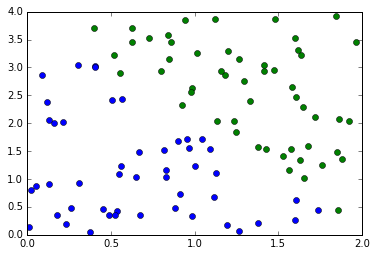

```python
m = 100
w = np.array([[2], [1], [-4]])

X = np.concatenate(((2*np.random.rand(m, 1)),(4*np.random.rand(m, 1)) ,np.ones((m, 1))), axis = 1 )
y = 0.5 < (np.exp(X.dot(w))/(1+np.exp(X.dot(w))))
y = y.astype(float)
c1 = np.where(y == 1)[0]
c2 = np.where(y == 0)[0]
y[c2] = -1
plt.plot(X[c1, 0], X[c1, 1], 'go', X[c2, 0], X[c2, 1], 'bo')
plt.show()
```

$$ \begin{align*} \ell(\omega) &= \log \mathscr{L} = \sum\limits_{i=1}^{q}{\log p_i} + \sum\limits_{i=q+1}^{m}{\log(1 - p_i)} \\ & = \sum\limits_{i=1}^{q}{\log \frac{\exp\left(\omega^T x_i\right)}{1 + \exp \left(\omega^T x_i \right)}} + \sum\limits_{i=q+1}^{m}{\log \frac{1}{1+\exp \left(\omega^T x_i \right)}} \\ &= \sum\limits_{i=1}^{q}{\left(\omega^T x_i\right)} - \sum\limits_{i=1}^{m}{\log \left(1+\exp \left(\omega^T x_i \right) \right)} \end{align*} $$

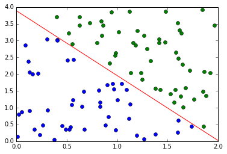

```python
y = np.matrix(y)
X = np.matrix(X)
w = cvx.Variable(3)
expr2 = [cvx.log_sum_exp(cvx.vstack(0, y[i]*X[i,:]*w)) for i in range(m)]
expr3 = sum(expr2)
obj = cvx.Minimize(expr3)
prob = cvx.Problem(obj)
prob.solve()

wsol = np.asarray(w.value)
xp = [x/10. for x in range(0, 21)]
yp = (-wsol[0]*xp - wsol[2])/wsol[1]
plt.plot(X[c1, 0], X[c1, 1], 'go', X[c2, 0], X[c2, 1], 'bo')
plt.plot(xp,yp,'r')
plt.show()
```

**In a more compact form**

Change $y \in \{0,+1\} \rightarrow y \in \{-1,+1\}$ for compuational convenience

- Consider the following function

$$P\left(y \mid x,\omega\right) = \sigma\left(y\omega^Tx\right) = \frac{1}{1+\exp\left(-y\omega^T x\right)} \in [0,1]$$

- Log-likelihood

$$ \begin{align*} \ell(\omega) = \log \mathscr{L} = \log P\left(y \mid x,\omega\right)& = \log \prod_{n=1}^{m} P\left(y_n \mid x_n,\omega\right)\\ &= \sum_{n=1}^{m} \log P\left(y_n \mid x_n,\omega\right)\\ &= \sum_{n=1}^{m} \log \frac{1}{1+\exp\left(-y_n\omega^T x_n\right)}\\ &= \sum\limits_{n=1}^{m}{-\log \left(1+\exp \left(-y_n\omega^T x_n \right) \right)} \end{align*} $$

- MLE solution

$$ \begin{align*} \hat{\omega} &= \arg \max_{\omega} \sum\limits_{n=1}^{m}{-\log \left(1+\exp \left(-y_n\omega^T x_n \right) \right)}\\ &= \arg \min_{\omega} \sum\limits_{n=1}^{m}{\log \left(1+\exp \left(-y_n\omega^T x_n \right) \right)} \end{align*} $$

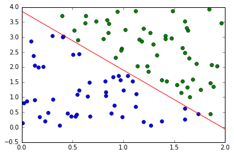

```python
y = np.matrix(y)
X = np.matrix(X)
w = cvx.Variable(3)
g = 1;
expr2 = [cvx.log_sum_exp(cvx.vstack(0, y[i]*X[i,:]*w)) for i in range(m)]
expr3 = sum(expr2)
obj = cvx.Minimize(g*cvx.norm2(w)+expr3)
prob = cvx.Problem(obj)
prob.solve()

wsol = np.asarray(w.value)
xp = [x/10. for x in range(0, 21)]
yp = (-wsol[0]*xp - wsol[2])/wsol[1]
plt.plot(X[c1, 0], X[c1, 1], 'go', X[c2, 0], X[c2, 1], 'bo')
plt.plot(xp,yp,'r')
plt.show()
```

## 1.4. Logistic Regression with Newton's Method (Optional)

$$ \begin{align*} \sigma(z) &= \frac{1}{1+e^{-z}}\\ \sigma'(z) &= \frac{e^{-z}}{\left(1+e^{-z}\right)^2} = \frac{1}{1+e^{-z}}\frac{e^{-z}}{1+e^{-z}} = \sigma(z)\left(1-\sigma(z)\right) \\ \\ J &= \ln \left(1+e^{-z}\right) \\ J' & = \frac{1}{1+e^{-z}} \cdot -e^{-z} = -\frac{e^{-z}}{1+e^{-z}} = -\frac{1}{1+e^{z}} \end{align*}$$

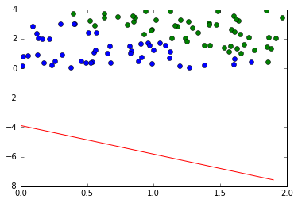

```python
y[y == 0] = -1
y = np.array(y)
X = np.array(X)
k = np.shape(X)[1]
w = np.zeros((k, 1))

g = 1.

while (np.linalg.norm(g) > 1e-10):
    z = 1/(1 + np.exp(y*(X.dot(w))))
    g = -(X.T).dot(z*y)
    H = (X.T).dot(np.diag((z*(1-z))[:,0])).dot(X)
    w = w - np.linalg.inv(H).dot(g)

xp = np.arange(0, 2, 0.1)
yp = (w[2]/w[1] - w[0]/w[1]*xp)

plt.plot(X[c1, 0], X[c1, 1], 'go')
plt.plot(X[c2, 0], X[c2, 1], 'bo')
plt.plot(xp, yp, 'r')
plt.show()
```

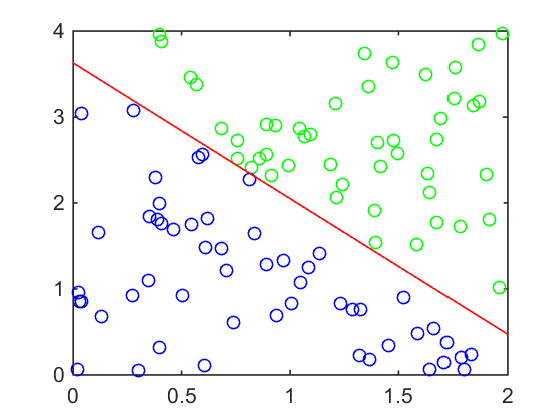

```python
## logistic regression using Newton's method


y(y == 0) = -1;

k = size(X,2);
w = zeros(k,1);

g = 1;

while (norm(g) > 1e-10)
    z = 1./(1 + exp(y.*(X*w)));
    g = -X'*(z.*y);
    H = X'*diag(z.*(1-z))*X;
    w = w - H\g;
end

%% plot
xp = 0:0.1:2;
yp = (-w(3) - w(1)*xp)./w(2);

plot(X(c1,1),X(c1,2),'go',X(c2,1),X(c2,2),'bo'),    hold on
plot(xp,yp,'r'),    hold off
```

## 1.5. Logistic Regression with Gradient Descent (Optional)

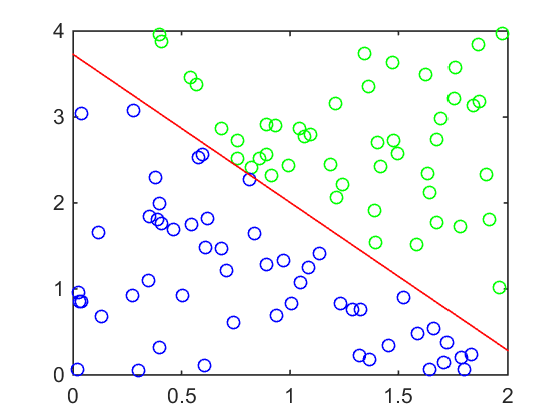

```python
%% logistic regression using gradient descent

clear w

y = double(y);
y(y == 0) = -1;

k = size(X,2);
w = randn(k,1);

eta = 1;

J = 1/m*sum(log(1 + exp(-y.*(X*w))));
preJ = inf;

%%
while abs(J-preJ)/J >= 1e-5
    z = 1./(1 + exp(y.*(X*w)));
    g = -1/m*X'*(z.*y);
    w = w - eta*g;

    preJ = J;
    J = 1/m*sum(log(1 + exp(-y.*(X*w))));
end

% plot
xp = 0:0.1:2;
yp = (-w(3) - w(1)*xp)./w(2);

plot(X(c1,1),X(c1,2),'go',X(c2,1),X(c2,2),'bo'),    hold on
plot(xp,yp,'r'),    hold off
```

## 1.6. Logistic Regression with Stochastic Gradient Descent (Optional)

- Logistic regression $$ \begin{align*} J(\omega) = \frac{1}{m} \,\sum\limits_{n=1}^{m}{\log \left(1+\exp \left(-y_n\omega^T x_n \right) \right)} \end{align*} $$
- Pick one $(x_n,y_n)$ at a time.
- Gradient given by:

$$ \begin{align*} \nabla_{\omega}J(\omega) &= - \frac{y_n x_n}{1+\exp \left(y_n\omega^T x_n \right)}= -\frac{1}{m}\,x_n^T z y_n\\ \end{align*} $$

where $$z = \frac{1}{1+\exp \left(y_n\omega^T x_n \right) }$$

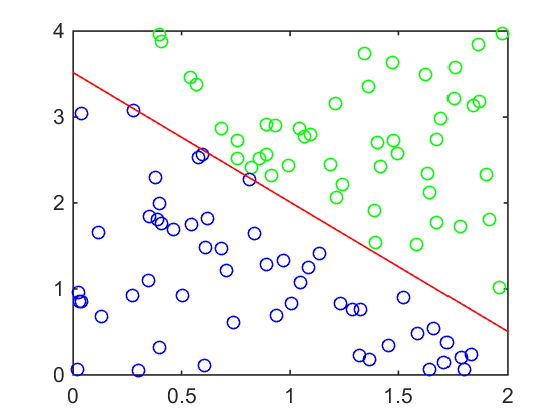

```python
%% logistic regression using stochastic gradient descent

clear w

y = double(y);
y(y == 0) = -1;

k = size(X,2);
w = randn(k,1);

eta = 0.1;

J = 1/m*sum(log(1 + exp(-y.*(X*w))));
preJ = inf;

%
while abs(J-preJ)/J >= 1e-10
    n = randi(m,1);
    z = 1./(1 + exp(y(n).*(X(n,:)*w)));
    g = -X(n,:)'*(z.*y(n));
    w = w - eta*g;

    preJ = J;
    J = 1/m*sum(log(1 + exp(-y.*(X*w))));
end

% plot
xp = 0:0.1:2;
yp = (-w(3) - w(1)*xp)./w(2);

figure(1),  clf
plot(X(c1,1),X(c1,2),'go',X(c2,1),X(c2,2),'bo'),    hold on
plot(xp,yp,'r'),    hold off
```

# 2. Regularized Logistic Regression

- $l_2$ regularized logistic regression
  - make $\omega$ small $$ \begin{align*} \min_{\omega} &\; \lambda \rVert \omega \lVert_2^2 + \sum\limits_{n=1}^{m}{\log \left(1+\exp \left(-y_n\omega^T x_n \right) \right)} \end{align*} $$
- $l_1$ regularized logistic regression
  - make $\omega$ small and sparse $\rightarrow$ feature selection for classification

$$ \begin{align*} \min_{\omega} &\; \lambda \rVert \omega \lVert_1 + \sum\limits_{n=1}^{m}{\log \left(1+\exp \left(-y_n\omega^T x_n \right) \right)} \end{align*} $$

- The effect of regularization will be more clearly illustrated with a non-linear data set

```python
%plot -s 560,420

% Generate data
rand('state',0);

m = 100;
w = [2;1;-4];

X = [2*rand(m,1) 4*rand(m,1) ones(m,1)];

y = 0.5 < exp(X*w)./(1+exp(X*w));

c1 = find(y == 1);
c2 = find(y == 0);

y = double(y);
y(y == 0) = -1;
```

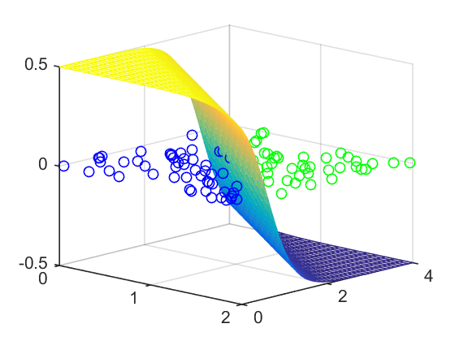

```python
%%
clear w
g = 1;

cvx_begin quiet
    variable w(3,1)
    minimize (g*norm(w,2) + sum(log_sum_exp([zeros(1,m); (y.*(X*w))'])))
cvx_end

[X1,X2] = meshgrid(0:0.1:2,0:0.1:4);

Z = exp(X1*w(1) + X2*w(2) + w(3))./(1 + exp(X1*w(1) + X2*w(2) + w(3)))-1/2; % plane shifted down to 1/2

plot3(X(c1,1),X(c1,2),zeros(length(c1),1),'go',X(c2,1),X(c2,2),zeros(length(c2),1),'bo'), hold on
mesh(X1,X2,Z), hold off
grid on, view(43,16)
```

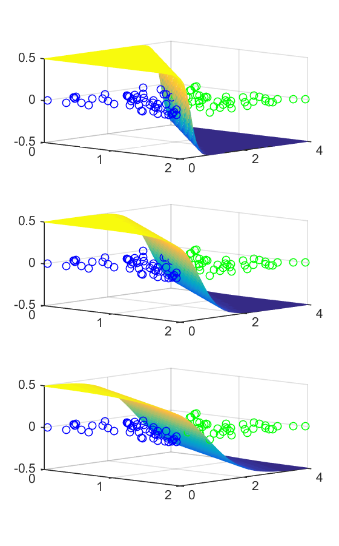

```python
%plot -s 560,900

clear w
g = [0.1 1 3];

for i = 1:3
    cvx_begin quiet
        variable w(3,1)
        minimize (g(i)*norm(w,2) + sum(log_sum_exp([zeros(1,m); (y.*(X*w))'])))
    cvx_end

    [X1,X2] = meshgrid(0:0.1:2,0:0.1:4);

    Z = exp(X1*w(1) + X2*w(2) + w(3))./(1 + exp(X1*w(1) + X2*w(2) + w(3)))-1/2; % plane shifted down to 1/2

    subplot(3,1,i),  plot3(X(c1,1),X(c1,2),zeros(length(c1),1),'go',X(c2,1),X(c2,2),zeros(length(c2),1),'bo'), hold on
    mesh(X1,X2,Z), hold off
    grid on, view(43,16)
end
```

- $l_1$ regularized logistic regression
  - make $\omega$ small and sparse $\rightarrow$ feature selection for classification

$$ \begin{align*} \min_{\omega} &\; \lambda \rVert \omega \lVert_1 + \sum\limits_{n=1}^{m}{\log \left(1+\exp \left(-y_n\omega^T x_n \right) \right)} \end{align*} $$

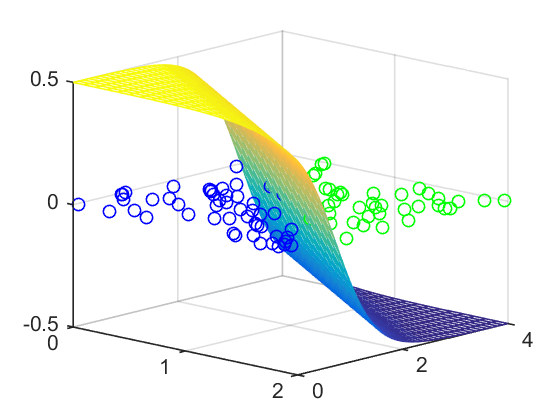

```python
%plot -s 560,420

clear w
g = 1;

cvx_begin quiet
    variable w(3,1)
    minimize (g*norm(w,1) + sum(log_sum_exp([zeros(1,m); (y.*(X*w))'])))
cvx_end

[X1,X2] = meshgrid(0:0.1:2,0:0.1:4);

Z = exp(X1*w(1) + X2*w(2) + w(3))./(1 + exp(X1*w(1) + X2*w(2) + w(3)))-1/2; % plane shifted down to 1/2

plot3(X(c1,1),X(c1,2),zeros(length(c1),1),'go',X(c2,1),X(c2,2),zeros(length(c2),1),'bo'), hold on
mesh(X1,X2,Z), hold off
grid on, view(43,16)
```

# 3. Multiclass Classification

- Generalization to more than 2 classes is straightforward
- Using the soft-max function instead of the logistic function

$$P\left(y = k \mid x,\omega\right) = \frac{\exp{\left( \omega_k^T x \right) }}{\sum_k \exp{\left(\omega_k^T x \right)}} \in [0,1]$$

- We maintain a separator weight vector $\omega_k$ for each class $k$

# 4. Non-linear Classification

- Same idea as for linear regression: non-linear features, either explicit or implicit Kernels

## 4.1. Explicit Feature Vector

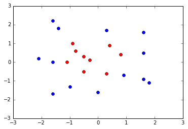

```python
x_c1 = np.array([[-1.1,  0], [-0.3,  0.1], [-0.9,  1],[0.8,  0.4],[0.4,  0.9],[0.3,-0.6],[-0.5, 0.3],
        [-0.8,  0.6],[-0.5, -0.5]])

x_c2 = np.array([[-1,  -1.3], [-1.6 , 2.2],  [0.9, -0.7],[1.6,  0.5],[1.8, -1.1],[1.6,  1.6],[-1.6, -1.7],
[-1.4,  1.8],[1.6, -0.9],[0, -1.6],[0.3, 1.7],[-1.6 , 0],[-2.1,0.2]])

plt.plot(x_c1[:, 0], x_c1[:,1], 'ro')
plt.plot(x_c2[:, 0], x_c2[:,1], 'bo')
plt.axis([-3,3,-3,3])
plt.show()
```

$$ x = \begin{bmatrix} x_1 \\ x_2 \end{bmatrix} \quad \Longrightarrow \quad z = \phi(x) = \begin{bmatrix} 1\\ \sqrt{2}x_1\\ \sqrt{2}x_2 \\x_1^2 \\ \sqrt{2}x_1 x_2 \\x_2^2 \end{bmatrix}$$

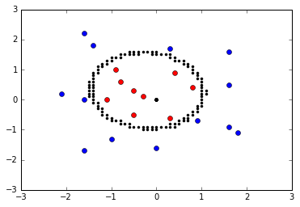

```python
c1n = x_c1.shape[0]
c2n = x_c2.shape[0]

X = np.concatenate((x_c1, x_c2), 0)
y = np.concatenate((np.ones((c1n, 1)), -np.ones((c2n, 1))), 0)


n = 3
m = c1n + c2n
g = 1

z = np.zeros((m, 6))

z[:, 0] = np.ones((m, ))
z[:, 1] = np.sqrt(2)*X[:, 0]
z[:, 2] = np.sqrt(2)*X[:, 1]
z[:, 3] = X[:, 0]**2
z[:, 4] = np.sqrt(2)*X[:, 0]*X[:, 1]
z[:, 5] = X[:, 1]**2

w = cvx.Variable(n, 1)




y = np.matrix(y)
X = np.matrix(X)
w = cvx.Variable(6)
g = 1;
expr2 = [cvx.log_sum_exp(cvx.vstack(0, y[i]*z[i,:]*w)) for i in range(m)]
expr3 = sum(expr2)
obj = cvx.Minimize(g*cvx.norm2(w)+expr3)
prob = cvx.Problem(obj)
prob.solve()

wsol = np.asarray(w.value)


wsolnormal = wsol/np.linalg.norm(wsol)*10
wsolnormal


[X1g, X2g] = np.meshgrid([x1/10. for x1 in range(-30,31,1)],[x2/10. for x2 in range(-30,31,1)])

x_test = np.concatenate((X1g.reshape(X1g.shape[0]**2,1, order ="F"), X2g.reshape(X2g.shape[0]**2,1, order = "F")), 1)
mtest = np.shape(x_test)[0]

z_test = np.zeros((mtest, 6))

z_test[:, 0] = np.ones((mtest, ))
z_test[:, 1] = np.sqrt(2)*x_test[:, 0]
z_test[:, 2] = np.sqrt(2)*x_test[:, 1]
z_test[:, 3] = x_test[:, 0]**2
z_test[:, 4] = np.sqrt(2)*x_test[:, 0]*x_test[:, 1]
z_test[:, 5] = x_test[:, 1]**2

y_hat = 1/(1+np.exp(-z_test.dot(wsolnormal)))

B = np.zeros((np.shape(y_hat)[0],2))

for i in range(0, y_hat.shape[0]):
    if np.abs(y_hat[i]-0.5) < 0.2:
        B[i,:] = x_test[i,:]

plt.plot(x_c1[:, 0], x_c1[:,1], 'ro')
plt.plot(x_c2[:, 0], x_c2[:,1], 'bo')
plt.axis([-3,3,-3,3])
plt.plot(B[:, 0], B[:, 1], 'k.')
plt.show()
```

- $l_2$ regularized logistic regression
  - non-linear and overfitting
  - make $\omega$ small $$ \begin{align*} \min_{\omega} &\; \lambda \rVert \omega \lVert_2^2 + \sum\limits_{n=1}^{m}{\log \left(1+\exp \left(-y_n\omega^T x_n \right) \right)} \end{align*} $$
- download [nonlinear_x.dat](https://www.dropbox.com/s/bsxxcahjm31gv9s/nonlinear_x.dat?dl=0)
- download [nonlinear_y.dat](https://www.dropbox.com/s/6939y9e8jm9xp55/nonlinear_y.dat?dl=0)

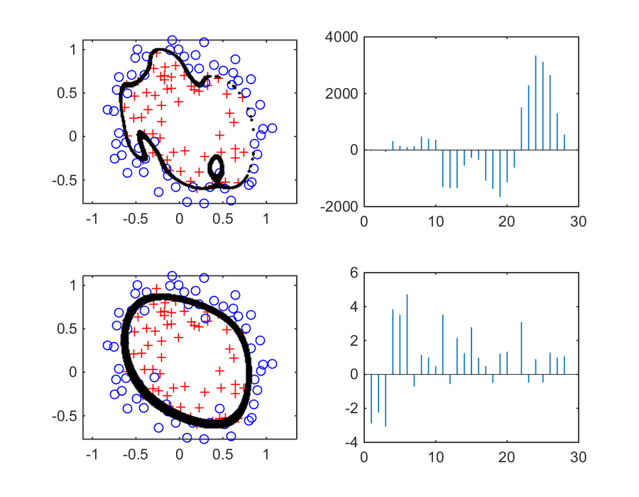

```python
%plot -s 900,700
% source: By Andrew Ng at Stanford Univ.
% http://openclassroom.stanford.edu/MainFolder/DocumentPage.php?course=MachineLearning&doc=exercises/ex5/ex5.html

X = load([pwd,'\image_files\nonlinear_x.dat']);
y = load([pwd,'\image_files\nonlinear_y.dat']);

y(y == 0) = -1;

pos = find(y+1);
neg = find(y-1);
plot(X(pos,1),X(pos,2),'r+',X(neg,1),X(neg,2),'bo')
axis equal

%% estimate w from regularized logistic regression for non-linear data
m = length(y);
d = 6;

% polynomial functions
Z = ones(m,1);
for i = 1:d
    for j = 0:i
        Z = [Z (X(:,1).^(i-j)).*(X(:,2).^j)];
    end
end

n = size(Z,2);

[X1g, X2g] = meshgrid(-3:0.01:3,-3:0.01:3);
X_test = [X1g(:) X2g(:)];

Z_test = ones(length(X_test),1);

for i = 1:d
    for j = 0:i
        Z_test = [Z_test (X_test(:,1).^(i-j)).*(X_test(:,2).^j)];
    end
end

g = [0 1];

for k = 1:length(g)
    clear w
    cvx_begin quiet
        variable w(n,1)
        minimize (g(k)*norm(w,2) + sum(log_sum_exp([zeros(1,m); (y.*(Z*w))'])))
    cvx_end

    y_hat = 1./(1 + exp(-Z_test*w));

    % plotting a decision boundary
    B = [];
    for i = 1:length(y_hat)
        if abs(y_hat(i)-0.5) < 0.1
            B = [B; X_test(i,:)];
        end
    end

    subplot(length(g),2,2*k-1), plot(X(pos,1),X(pos,2),'r+',X(neg,1),X(neg,2),'bo'), hold on
    plot(B(:,1),B(:,2),'k.'),   hold off, axis equal
    subplot(length(g),2,2*k), stem(w,'marker','none')
end
```

- $l_1$ regularized logistic regression
  - nonlinear, overfitting, and too many features
  - make $\omega$ small and sparse $\rightarrow$ feature selection for classification

$$ \begin{align*} \min_{\omega} &\; \lambda \rVert \omega \lVert_1 + \sum\limits_{n=1}^{m}{\log \left(1+\exp \left(-y_n\omega^T x_n \right) \right)} \end{align*} $$

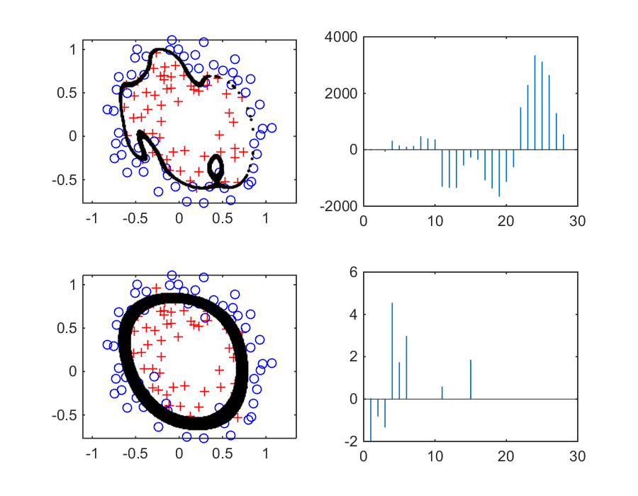

```python
%plot -s 900,700
X = load([pwd,'\image_files\nonlinear_x.dat']);
y = load([pwd,'\image_files\nonlinear_y.dat']);

y(y == 0) = -1;

pos = find(y+1);
neg = find(y-1);
plot(X(pos,1),X(pos,2),'r+',X(neg,1),X(neg,2),'bo')
axis equal

%% estimate w from regularized logistic regression for non-linear data
m = length(y);
d = 6;

% polynomial functions
Z = ones(m,1);
for i = 1:d
    for j = 0:i
        Z = [Z (X(:,1).^(i-j)).*(X(:,2).^j)];
    end
end

n = size(Z,2);

[X1g, X2g] = meshgrid(-3:0.01:3,-3:0.01:3);
X_test = [X1g(:) X2g(:)];

Z_test = ones(length(X_test),1);

for i = 1:d
    for j = 0:i
        Z_test = [Z_test (X_test(:,1).^(i-j)).*(X_test(:,2).^j)];
    end
end

g = [0 1];

for k = 1:length(g)
    clear w
    cvx_begin quiet
        variable w(n,1)
        minimize (g(k)*norm(w,1) + sum(log_sum_exp([zeros(1,m); (y.*(Z*w))'])))
    cvx_end

    y_hat = 1./(1 + exp(-Z_test*w));

    % plotting a decision boundary
    B = [];
    for i = 1:length(y_hat)
        if abs(y_hat(i)-0.5) < 0.1
            B = [B; X_test(i,:)];
        end
    end

    subplot(length(g),2,2*k-1), plot(X(pos,1),X(pos,2),'r+',X(neg,1),X(neg,2),'bo'), hold on
    plot(B(:,1),B(:,2),'k.'),   hold off, axis equal
    subplot(length(g),2,2*k), stem(w,'marker','none')
end
```

## 4.2. Implicit Feature Vector (Kernel)

```python
%%javascript
$.getScript('https://kmahelona.github.io/ipython_notebook_goodies/ipython_notebook_toc.js')
```